# Practical Machine Learning - Programming Assignment

Miguel Duarte B.

01/15/2021

# NOTES FOR REVIEWERS

- I’m using GitHub Pages functionality that allows HTML code to be posted as a web page ([this webpage](https://migueldb.github.io/C8PA/)). If you want to review the rMarkdown file and the complete repository, please check the following link: https://github.com/migueldb/C8PA
- The selected measure for Sample Error estimation is *Accuracy* which is calculated multiple times throughout the document
- Cross validation is performed on each one of the model fits using k-fold method using the *trControl = trainControl()* option of the function *train*.

## Introduction

This work is a programming assignment submission for the Practical Machine Learning course with the Johns Hopkins University through Coursera. The goal of this project is to use data from accelerometers to conduct qualitative activity recognition of weight lifting exercises. The data provided is a csv file with 159 columns and 19,622 rows. The student is expected to use the R-package ‘caret’ and apply any, or a combination, of the Machine Learning techniques learned during the course to correctly identify the specified execution of the exercise represented with the variable “classe”.

## Background

The data was collected from six young individuals who were asked to perform one set of 10 repetitions of the Unilateral Dumbbell Biceps Curl in five different fashions, where Class A is the correct execution and Classes B - E represent common mistakes in execution (Velloso 2013).

Using devices such as Jawbone Up, Nike FuelBand, and Fitbit it is now possible to collect a large amount of data about personal activity relatively inexpensively. These type of devices are part of the quantified self movement – a group of enthusiasts who take measurements about themselves regularly to improve their health, to find patterns in their behavior, or because they are tech geeks. One thing that people regularly do is quantify how much of a particular activity they do, but they rarely quantify how well they do it. In this project, your goal will be to use data from accelerometers on the belt, forearm, arm, and dumbbell of 6 participants. They were asked to perform barbell lifts correctly and incorrectly in 5 different ways. More information is available from the website here: http://groupware.les.inf.puc-rio.br/har (see the section on the Weight Lifting Exercise Dataset).

## Preprocessing

First, the required libraries are loaded and a random number generator seed is set for reproducibility.

```r
library(readr); library(dplyr); library(lubridate); library(caret); library(AppliedPredictiveModeling)
library(doParallel); library(randomForest); library(cvms); library(gridExtra) # Load libraries

set.seed(2021) # Set random generator seed
```

### Collect The Data

Next, the data from the server is downloaded and stored in the raw folder. The downloaded files in the raw folder will be used if they exist otherwise the script will download a new set of files. An unmodified copy of the data is stored using the data frames *trainingSRC* and *evaluationSRC* with explicit declaration of column types.

```r
# Source files URLs
trainingURL <- "https://d396qusza40orc.cloudfront.net/predmachlearn/pml-training.csv"
evaluationURL <- "https://d396qusza40orc.cloudfront.net/predmachlearn/pml-testing.csv"

rawFolder <- file.path(getwd(), "raw"); trainingFile <- file.path(rawFolder, "training.csv")
evaluationFile <- file.path(rawFolder, "evaluation.csv") # Assign variables for raw folder and source file names

# Check if the files have been downloaded and stored already, if not download and save them to the raw folder
if(!file.exists(rawFolder)){dir.create(rawFolder)}
if(!file.exists(trainingFile)){download.file(trainingURL, trainingFile)}
if(!file.exists(evaluationFile)){download.file(evaluationURL, evaluationFile)}

# Define column types explicitly
col_typesTraining <- cols(.default = col_double(), X1 = col_skip(), user_name = col_character(), cvtd_timestamp = col_character(), new_window = col_factor(), classe = col_factor())

col_typesEvaluation <- cols(.default = col_double(), X1 = col_skip(), user_name = col_character(), cvtd_timestamp = col_character(), new_window = col_factor(), problem_id = col_integer())

# Create training and evaluation data frames with the unmodified data from the source files
trainingSRC <- read_csv(trainingFile, col_types = col_typesTraining)
evaluationSRC <- read_csv(evaluationFile, col_types = col_typesEvaluation)
```

### Clean The Data

It can be noted that the data sets provided have numerous empty columns, these empty columns are identified and removed before splitting the training data set into training and testing. The columns with information irrelevant to the classification problem are identified as well for removal. Finally, it can be also noticed that the *evaluation* data used for the final quiz has additional empty columns, this means that the corresponding predictors won’t be available to build predictions from the fitted models, therefore it is required to remove these columns (variables) from the *training* and *testing* data sets as well.

```r
# Identify the columns with no information (empty columns)
dropTraining <- names(trainingSRC[, sapply(trainingSRC, function(x)all(is.na(x)))])
dropEvaluation <- names(evaluationSRC[, sapply(evaluationSRC, function(x)all(is.na(x)))])

# Identify additional columns with information that is not relevant to the prediction
dropAdd <- c("user_name", "raw_timestamp_part_1", "raw_timestamp_part_2", "cvtd_timestamp", "new_window", "num_window")

# Create training and evaluation data frames with only the relevant columns (variables) to the classification exercise
trainingClean <- trainingSRC %>%
    mutate(raw_timestamp_part_1 = as_datetime(raw_timestamp_part_1)) %>%
    select(-all_of(c(dropEvaluation, dropAdd)))

evaluationClean <- evaluationSRC %>%
    mutate(raw_timestamp_part_1 = as_datetime(raw_timestamp_part_1)) %>%
    select(-all_of(c(dropEvaluation, dropAdd)))

# Two sets of split data (mini and full) are generated to expedite the model selection process by using a smaller training data set.  In the last run only the *fullTraining* and *fullTesting* datasets are used.
fullInTrain <- createDataPartition(y=trainingClean$classe, p = 0.75, list = FALSE)
fullTesting <- trainingClean[-fullInTrain, ]
fullTraining <- trainingClean[fullInTrain, ]

miniInTrain <- createDataPartition(y=trainingClean$classe, p = 0.1, list = FALSE)
miniTesting <- trainingClean[-miniInTrain, ]
miniTraining <- trainingClean[miniInTrain, ]

training <- fullTraining
testing <- fullTesting
```

## Preliminary Analysis

The variable importance evaluation functions can be used to show the impact each one of the predictors or variables have on the classification process. The package *randomForest* includes the function *importance* which helps understanding the correlation structure. For visualization purposes only the top 4 most important variables are selected for display with a feature plot. It is clear that there’s no clear separation between the classes for the selected predictors as the color clouds superpose on the feature plots.

```r
# Fit a Random Forest model required to estimate the variable's importance ranking
importanceRF <- randomForest(classe ~ ., data = miniTraining)

# Create a data frame with the variables sorted by importance and print the top 4
importanceDF <- as.data.frame(importance(importanceRF), optional = TRUE)
importanceDF$name <- row.names(importanceDF)
importanceDF <- importanceDF[order(importanceDF$MeanDecreaseGini, decreasing = TRUE), ]
print(head(importanceDF))
```

```
##                   MeanDecreaseGini              name
## roll_belt                 98.68114         roll_belt
## pitch_forearm             73.11862     pitch_forearm
## magnet_dumbbell_z         68.01211 magnet_dumbbell_z
## yaw_belt                  66.18923          yaw_belt
## magnet_dumbbell_y         60.34180 magnet_dumbbell_y
## magnet_dumbbell_x         55.66641 magnet_dumbbell_x
```

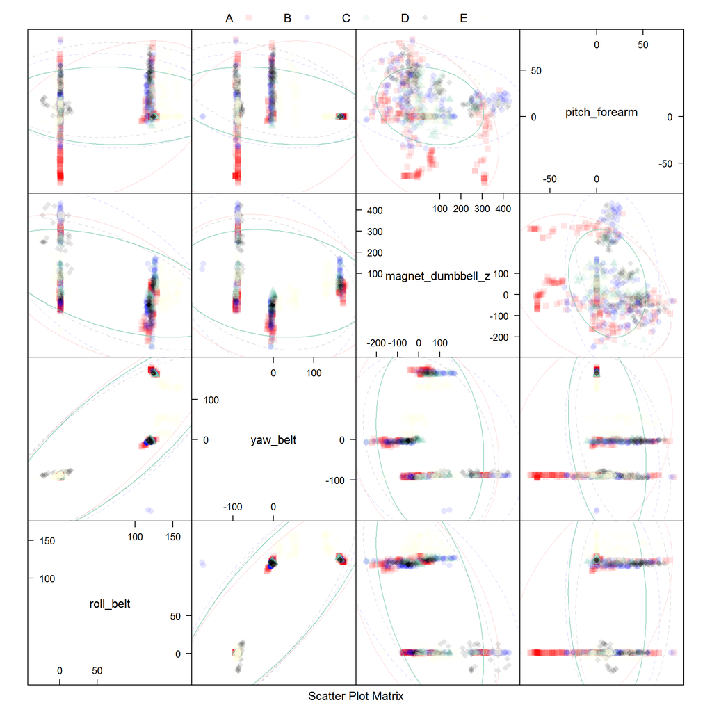

Fig. 1 - Feature plot showing the top-4 variables by importance plotted against each other. The predictand *classe* is represented by color.

```r
# Create a logic vector where only the top variables by importance are set to TRUE
varsImportance <- names(testing) %in% head(importanceDF, 4)$name

# Create a feature plot with the top 4 variables by importance
transparentTheme(trans = .1) # Select theme
# Useful functions
#show.settings()
#trellis.par.get()
#myColors <- c("light pink", "light blue", "light green", "thistle1", "light yellow") # Modify theme colors
myColors <- c("#FF00001A", "#0000FF1A", "#66C1A41A", "#0000001A", "#FFFFE01A")
mySettings <- list(superpose.symbol = list(col = myColors, pch = 15:19))
trellis.par.set(mySettings) # Modify theme superpose symbol settings

randSample <- sort(sample.int(dim(training)[1],1000)) # Use a smaller random sample to make easier to spot the class clouds

featurePlot(x = training[randSample, varsImportance],  y = training$classe[randSample], plot = "ellipse", auto.key = list(columns = 5)) # And finally generate the plot
```

## Fit models

Six different models are fitted and compared in terms of accuracy, taking advantage of the *parallel* library to expedite the models fitting.

```r
cl <- makePSOCKcluster(3)
registerDoParallel(cl)
```

### Model 1 - Random Forest

Random forests are one of the top performing algorithms for multi-class classification, therefore this is one of the first algorithms to consider. A Random Forest model is fit using default pre-processing settings using k-fold method with k = 3 for *Cross Validation* passed through the training control option.

```r
mod1 <- train(classe ~ ., method="rf", data=training, trControl = trainControl(method = "cv", 3))
```

### Model 2 - Naive Bayes

Naive Bayes algorithm assumes that all the variables are uncorrelated. This algorithm helps obtaining a baseline for the accuracy of the data set by counting the occurrence of each variable attribute with each class. k-fold method with k = 30 will be used For *Cross Validation* passed through the training control option.

```r
mod2 <- train(classe ~ ., method="naive_bayes", data=training, trControl = trainControl(method = "cv", 30))
```

### Model 3 - Extreme Gradient Boosting

XGBoost belongs to the family of gradient boosting algorithms which combine or ensemble weak classification models. k-fold method with k = 3 will be used For *Cross Validation* passed through the training control option.

```r
mod3 <- train(classe ~ ., method="xgbTree", data=training, trControl = trainControl(method = "cv", 3))
```

### Model 4 - Quadratic Discriminant Analysis

This method estimates the covariance matrix separately for each class using a quadratic discriminant function. QDA is an improvement to the Linear Discriminant Analysis (LDA). k-fold method with k = 30 will be used For *Cross Validation* passed through the training control option.

```r
mod4 <- train(classe ~ ., method="qda", data=training, trControl = trainControl(method = "cv", 30))
```

### Model 5 - Support Vector Machine with Polynomial Kernel

The SVM method creates hyperplanes in multi-dimensional spaces that effectively separates the distinct classes. This implementation in caret takes important time to compute therefore for *Cross Validation* the k-fold method was implemented with only k = 3 passed through the training control option.

```r
mod5 <- train(classe ~ ., method="svmPoly", data=training, trControl = trainControl(method = "cv", 3))
```

### Model 6 - k-Nearest Neighbors

This algorithm generates an output based on the *k* closest training examples, in the case of classification, this output is a class membership. This method has no training method and it’s easy to implement. k-fold method with k = 30 will be used For *Cross Validation* passed through the training control option.

```r
mod6 <- train(classe ~ ., method="kknn", data=training, trControl = trainControl(method = "cv", 30))
```

```r
stopCluster(cl)
registerDoSEQ()
```

## Build Predictions

A set of six predictions is built using the fitted models applied to the testing dataset. Later a table with the accuracy values is displayed for comparison.

```r
pred1 <- predict(mod1, testing)
pred2 <- predict(mod2, testing)
pred3 <- predict(mod3, testing)
pred4 <- predict(mod4, testing)
pred5 <- predict(mod5, testing)
pred6 <- predict(mod6, testing)

accuracyDF <- data.frame(
  c("Random Forest", "Naive Bayes", "Extreme Gradient Boosting", "Quadratic Discriminant Analysis", "Support Vector Machine", "k-Nearest Neighbors"),
  c(
    confusionMatrix(pred1, testing$classe)$overall["Accuracy"],
    confusionMatrix(pred2, testing$classe)$overall["Accuracy"],
    confusionMatrix(pred3, testing$classe)$overall["Accuracy"],
    confusionMatrix(pred4, testing$classe)$overall["Accuracy"],
    confusionMatrix(pred5, testing$classe)$overall["Accuracy"],
    confusionMatrix(pred6, testing$classe)$overall["Accuracy"]
  )
)

names(accuracyDF) <- c("Model", "Accuracy")

print(accuracyDF)
```

```
##                             Model  Accuracy
## 1                   Random Forest 0.9940865
## 2                     Naive Bayes 0.7479608
## 3       Extreme Gradient Boosting 0.9949021
## 4 Quadratic Discriminant Analysis 0.8921289
## 5          Support Vector Machine 0.9940865
## 6             k-Nearest Neighbors 0.9893964
```

### Expected Sample Error

From the accuracy data frame we see how the different models perform. The expected sample error can be visualized using scatter plot comparing the predicted values for each pair of predictors. For simplicity only the 3-top performing algorithms are selected for display.

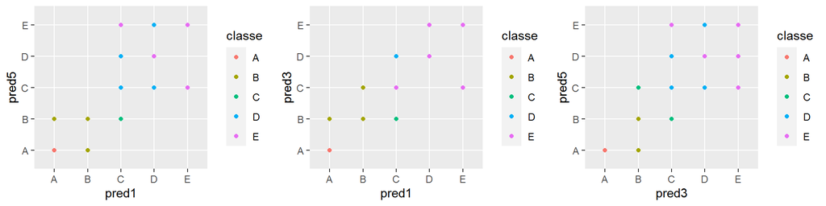

Fig. 2 - Triplet of plots showing how each pair of predictions compare in terms of accuracy. The true value of the predictand *classe* is represented with color

```r
p1 <- qplot(pred1, pred5, color=classe, data=testing)
p2 <- qplot(pred1, pred3, color=classe, data=testing)
p3 <- qplot(pred3, pred5, color=classe, data=testing)

grid.arrange(p1, p2, p3, nrow = 1)
```

## Ensemble Best Performing Models

An ensemble model is created using the top-3 best performing models identified in the previous section. The confusion matrix plot below provides a picture of the accuracy performance of the ensemble model. As expected we see a modest increment of the accuracy in the combined model in comparison with the individual models.

```r
predDF <- data.frame(pred1, pred3, pred5, classe = testing$classe)

combModFit <- train(classe ~ ., method = "rf", data = predDF)
combPred <- predict(combModFit, predDF)

confusionMatrix(combPred, testing$classe)$overall["Accuracy"]
```

```
##  Accuracy
## 0.9967374
```

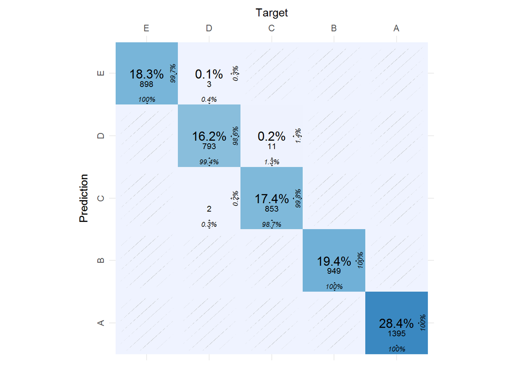

Fig. 3 - Confusion matrix plot for the ensemble model

```r
plot_confusion_matrix(confusion_matrix(combPred, testing$classe))
```

## Predicted values for the evaluation data

The final quiz requires the student to predict the value of *classe* given 20 new data points. Using the ensemble model by combining the model fits from the top-performing models in a single data frame a new and prediction is produced based on the new data (*evaluation* dataset)

```r
evaluation <- evaluationClean[1,-53] # remove problem_id column
pred1V <- predict(mod1, evaluationClean); pred3V <- predict(mod3, evaluationClean); pred5V <- predict(mod5, evaluationClean)
predVDF <- data.frame(pred1 = pred1V, pred3 = pred3V, pred5 = pred5V) # Dataframe combining predictions
predEval <- predict(combModFit, predVDF)

print(predEval)
```

```
##  [1] B A B A A E D B A A B C B A E E A B B B
## Levels: A B C D E
```

## Conclusion

There are numerous machine learning methods for multi-class classification, each one of them with advantages and disadvantages. Trial-and-error and learning in detail about each method is required to make a good judgment as to which one is better at solving particular classification problems. Finally, creating an ensemble may help improving the accuracy slightly.

# References

Velloso, A.; Gellersen, E.; Bulling. 2013. “Qualitative Activity Recognition of Weight Lifting Exercises.” In *Proceedings of 4th International Conference in Cooperation with Sigchi*, 116–23. Augmented Human ’13. Stuttgart, Germany: ACM SIGCHI.